# 02 - External Database Matches Visualization

## Overview

This notebook visualizes the distribution of compounds matched to external chemical databases across different food categories in the PTFI dataset.

## Background

After matching PTFI metabolomic features against external databases (DrugBank, FCCdb, and Agrochemical PubChem), we analyze how these database matches are distributed across food categories and identify the top food sources for compounds of interest.

## Input Data

**`matched_data.csv`** - PTFI features with external database match flags

**`df_long.csv`** - PTFI long format data

## Outputs

1. **Heatmap**: Mean intensity of matched compounds across FoodOn Level 1 categories and databases
2. **Bar plots**: Top 10 food sources for four selected bioactive compounds

## Analysis Approach

We focus on compounds that matched to at least one external database and calculate mean intensities across food categories to identify patterns of distribution in food.

```python
import pandas as pd
import matplotlib.pyplot as plt
import seaborn as sns
import numpy as np
from matplotlib.ticker import MaxNLocator

## Step 1: Load and integrate data

# Load PTFI long data
df_long = pd.read_csv("ptfi_data_long.csv")
print(f"Loaded {len(df_long)} PTFI features")

# Load metadata for FoodOn categories
metadata = pd.read_csv("ptfi_metadata.csv")
print(f"Loaded metadata for {len(metadata)} samples")

# Load external database matches
matched_dict = pd.read_csv("matched_data.csv")
print(f"Loaded {len(matched_dict)} metabolite matches")

# Merge long data with database matches
df_matched = df_long.merge(matched_dict[["metabolite","element_id","drugs", "drug_bank", "pubchem_drug", "fcc", "agro"]], on='metabolite', how='inner')

# Merge with metadata to get FoodOn categories
df_matched = df_matched.merge(
    metadata[['sample_id', 'foodon_level1_name', 'foodon_level2_name',
              'foodon_level3_name', 'foodon_level4_name']],
    on='sample_id',
    how='inner'
)

print(f"Final integrated dataset: {df_matched.shape}")
df_matched.head()
```

```
Loaded 9814700 PTFI features
Loaded metadata for 490 samples
Loaded 55632 metabolite matches
Final integrated dataset: (27259680, 16)
```

|  | sample_id | sample_foodon_leaf_name | metabolite | intensity | element_id_x | element_name | element_id_y | drugs | drug_bank | pubchem_drug | fcc | agro | foodon_level1_name | foodon_level2_name | foodon_level3_name | foodon_level4_name |
| --- | --- | --- | --- | --- | --- | --- | --- | --- | --- | --- | --- | --- | --- | --- | --- | --- |
| 0 | GGB100007 | yellow bell pepper (raw) | MET_AIONOLUJZLIMTK-AWEZNQCLSA-N | 0.0 | MET_AIONOLUJZLIMTK-AWEZNQCLSA-N | Hesperetin | MET_AIONOLUJZLIMTK-AWEZNQCLSA-N | True | True | False | False | False | plant food product | vegetable food product | plant fruit food product | plant fruit as vegetable food product |
| 1 | GGB100007 | yellow bell pepper (raw) | MET_AIONOLUJZLIMTK-AWEZNQCLSA-N | 0.0 | MET_AIONOLUJZLIMTK-AWEZNQCLSA-N | Hesperetin | MET_AIONOLUJZLIMTK-AWEZNQCLSA-N | True | True | False | False | False | plant food product | vegetable food product | plant fruit food product | plant fruit as vegetable food product |
| 2 | GGB100007 | yellow bell pepper (raw) | MET_AIONOLUJZLIMTK-AWEZNQCLSA-N | 0.0 | MET_AIONOLUJZLIMTK-AWEZNQCLSA-N | Hesperetin | MET_AIONOLUJZLIMTK-AWEZNQCLSA-N | True | True | False | False | False | plant food product | vegetable food product | plant fruit food product | plant fruit as vegetable food product |
| 3 | GGB100007 | yellow bell pepper (raw) | MET_AIONOLUJZLIMTK-AWEZNQCLSA-N | 0.0 | MET_AIONOLUJZLIMTK-AWEZNQCLSA-N | Hesperetin | MET_AIONOLUJZLIMTK-AWEZNQCLSA-N | True | True | False | False | False | plant food product | vegetable food product | plant fruit food product | plant fruit as vegetable food product |
| 4 | GGB100007 | yellow bell pepper (raw) | MET_AIONOLUJZLIMTK-AWEZNQCLSA-N | 0.0 | MET_AIONOLUJZLIMTK-AWEZNQCLSA-N | Hesperetin | MET_AIONOLUJZLIMTK-AWEZNQCLSA-N | True | True | False | False | False | plant food product | vegetable food product | plant fruit food product | plant fruit as vegetable food product |

```python
## Step 2: Filter for matched compounds only

# Keep only features that matched at least one database
df_matched_only = df_matched[
    (df_matched['drugs'] == True) |
    (df_matched['fcc'] == True) |
    (df_matched['agro'] == True)
].copy()

print(f"Features with database matches: {len(df_matched_only)}")
print(f"Unique metabolites matched: {df_matched_only['metabolite'].nunique()}")
```

[output not shown]

## Figure 1: Heatmap - Database Matches by Food Category

This heatmap shows the mean intensity of compounds that matched to each external database, grouped by top-level food categories (FoodOn Level 1).

```python
# Melt data to long format for databases
melted = df_matched_only.melt(
    id_vars=['foodon_level1_name', 'intensity'],
    value_vars=['drugs', 'fcc', 'agro'],
    var_name='database_type',
    value_name='match'
)

# Calculate mean intensity for matches only
pivot_df = melted[melted['match']].pivot_table(
    values='intensity',
    index='foodon_level1_name',
    columns='database_type',
    aggfunc='mean'
)

# Rename columns to full database names
column_mapping = {
    'agro': 'Agrochemical PubChem',
    'drugs': 'DrugBank',
    'fcc': 'FCCdb'
}
pivot_df.rename(columns=column_mapping, inplace=True)

# Sort by total abundance across databases
pivot_df['total'] = pivot_df.sum(axis=1)
pivot_df_sorted = pivot_df.sort_values('total', ascending=False).drop('total', axis=1)

# Reorder columns
column_order = ['DrugBank', 'FCCdb', 'Agrochemical PubChem']
pivot_df_final = pivot_df_sorted[column_order]


# Remove multi-component food product category
pivot_df_final = pivot_df_final[pivot_df_final.index != 'multi-component food product']

# Display the filtered data
print("Mean intensities by food category and database:")
pivot_df_final
```

[output not shown]

```python
pivot_df_final
```

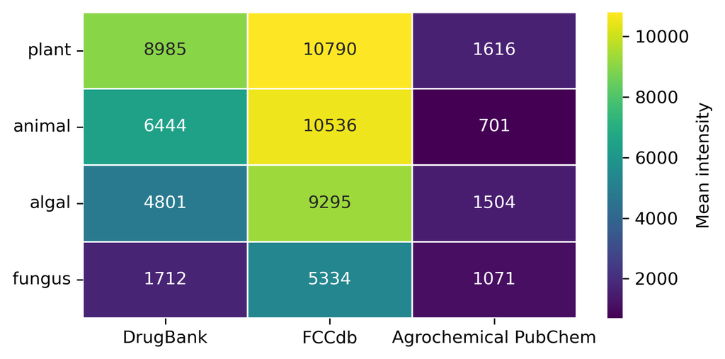

```python
# Create heatmap
plt.figure(figsize=(6, 3), dpi=300)
sns.heatmap(
    pivot_df_final,
    annot=True,
    fmt='.0f',
    cmap='viridis',
    linewidths=0.5,
    cbar_kws={'label': 'Mean intensity'}
)

plt.xlabel('')
plt.ylabel('')

# Clean y-axis labels (remove "food product")
ax = plt.gca()
ax.set_yticklabels([label.replace(' food product', '') for label in pivot_df_final.index])

plt.tight_layout()
#plt.savefig('results/heatmap_foodon1_databases.png', dpi=300, bbox_inches='tight')
plt.show()
```

## Figure 2: Top Food Sources for Selected Compounds

We examine the top 10 food sources (by mean intensity) for four compounds of interest that matched to external databases. These compounds represent different chemical classes and demonstrate diverse distribution patterns across food types.

```python
# Define compounds of interest
compounds = {
    'Rotenone': 'Rotenone',
    'Phlorizin': 'Phlorizin',
    'Pulegone': '(+)-Pulegone|Pulegone',
    'Rosmarinic acid': 'Rosmarinic acid'
}

# Prepare data for each compound
compound_data = {}

for title, element_name in compounds.items():
    # Filter for compound
    data = df_matched_only[df_matched_only["element_name"] == element_name].copy()

    # Special filter for Rosmarinic acid (animal products only)
    if title == 'Rosmarinic acid':
        data = data[data["foodon_level1_name"] == "animal food product"]

    # Get top 10 food sources by mean intensity
    top_foods = (data.groupby("sample_foodon_leaf_name")["intensity"]
                     .mean()
                     .reset_index()
                     .sort_values("intensity", ascending=False)
                     .head(10))

    # Keep only non-zero intensities
    top_foods = top_foods[top_foods["intensity"] > 0]

    compound_data[title] = top_foods
    print(f"{title}: {len(top_foods)} food sources with non-zero intensity")
```

```
Rotenone: 10 food sources with non-zero intensity
Phlorizin: 10 food sources with non-zero intensity
Pulegone: 5 food sources with non-zero intensity
Rosmarinic acid: 2 food sources with non-zero intensity
```

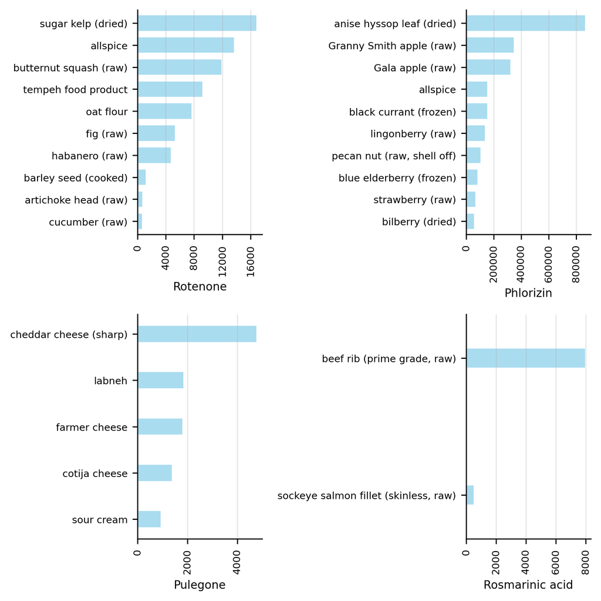

```python
# Create 2x2 subplot grid
fig, ((ax1, ax2), (ax3, ax4)) = plt.subplots(2, 2, figsize=(6, 6), dpi=300)
plt.subplots_adjust(hspace=0.4, wspace=0.3)

axes = [ax1, ax2, ax3, ax4]
titles = list(compounds.keys())

# Plot each compound
for ax, title in zip(axes, titles):
    data = compound_data[title]

    # Sort by intensity (ascending for horizontal bars)
    sorted_data = data.sort_values('intensity', ascending=True)
    sorted_data = sorted_data.set_index('sample_foodon_leaf_name')

    # Plot horizontal bar chart
    sorted_data['intensity'].plot(
        kind='barh',
        ax=ax,
        color='skyblue',
        alpha=0.7,
        width=sorted_data.shape[0] * 0.07
    )

    # Formatting
    ax.set_xlabel(title, fontsize=8)
    ax.set_ylabel('', fontsize=8)
    ax.tick_params(labelsize=7)
    ax.xaxis.set_major_locator(MaxNLocator(nbins=5, steps=[1, 2, 4, 6, 10]))
    ax.tick_params(axis='x', rotation=90)

    # Clean styling
    ax.spines['top'].set_visible(False)
    ax.spines['right'].set_visible(False)
    ax.grid(True, alpha=0.3, axis='x')

plt.tight_layout()
#plt.savefig('top_compounds_by_food.png', dpi=300, bbox_inches='tight', facecolor='white')
plt.show()
```

```python
import os

os.system('jupyter nbconvert --to html ptfi_external_db_matches.ipynb')
```

```
[NbConvertApp] Converting notebook ptfi_external_db_matches.ipynb to html
[NbConvertApp] Writing 303120 bytes to ptfi_external_db_matches.html
```

```
0
```